# LThomson_DATA605_Final

Logan Thomson

December 10, 2016

## DATA 605 - COMPUTATIONAL MATHEMATICS, FINAL

```r
library(e1071)
library(pander)
library(ggplot2)
library(reshape2)
library(MASS)
```

### Load Data from Kaggle

```r
# Load training data from GitHub
path <- ('https://raw.githubusercontent.com/Logan213/DATA605_Final/master/train.csv')
con <- file(path, open="r")
train <- read.csv(con, header=T, stringsAsFactors = F)
close(con)

# Load test data from GitHub
path <- ('https://raw.githubusercontent.com/Logan213/DATA605_Final/master/test.csv')
con <- file(path, open="r")
test <- read.csv(con, header=T, stringsAsFactors = F)
close(con)
```

### Define X & Y Variables

Pick one of the quantitative independent variables from the training data set (train.csv), and define that variable as X. Make sure this variable is skewed to the right! Pick the dependent variable and define it as Y.

Looking at the mean and median values of each variable, as given by the `summary` function, we can choose our right-skewed variable to represent “X” by using a predictor whose mean is larger than the median. The variables that appear to be the most right-skewed are `LotArea`, `TotalBsmtSF`, `GrLivArea`, `X1stFlrSF`, `BsmtFinSF1`, `MasVnrArea`, `OverallCond`. `LotArea` seems to be more skewed than the others, so this will be chosen as our X variable. `SalePrice` is the dependent variable, and we will define it as Y.

```r
X <- train$LotArea
Y <- train$SalePrice
```

### Probability.

Calculate as a minimum the below probabilities a through c. Assume the small letter “x” is estimated as the 3d quartile of the X variable, and the small letter “y” is estimated as the 2d quartile of the Y variable. Interpret the meaning of all probabilities.

```r
# obtain quartiles for X
quantile(X)
```

```
##       0%      25%      50%      75%     100%
##   1300.0   7553.5   9478.5  11601.5 215245.0
```

For the X variable, the 3<sup>rd</sup> quartile is 11601.5. 25% of the case have a `LotArea` equal to this or larger.

```r
# obtain quartiles for Y
quantile(Y)
```

```
##     0%    25%    50%    75%   100%
##  34900 129975 163000 214000 755000
```

For the Y variable, the 2<sup>nd</sup> quartile is 163000. 50% of the cases have a `SalePrice` equal to this or lower, while 50% are above this sale price ($\geq$ $163,000.01).

#### Make a table of counts.

```r
# set counts of quartiles for X and Y
leq_3d_qtl <- X <= 11601.5
grtr_3d_qtl <- X > 11601.5

leq_2d_qtl <- Y <= 163000
grtr_2d_qtl <- Y > 163000

# Table First Row
row1_1 <- sum(leq_3d_qtl & leq_2d_qtl)  # <= x and <= y
row1_2 <- sum(leq_3d_qtl & grtr_2d_qtl)  # <= x and > y
row1_tot <- row1_1 + row1_2

# Table Second Row
row2_1 <- sum(grtr_3d_qtl & leq_2d_qtl)  # > x and <= y
row2_2 <- sum(grtr_3d_qtl & grtr_2d_qtl)  # > x and > y
row2_tot <- row2_1 + row2_2

#Totals
col1_tot <- row1_1 + row2_1
col2_tot <- row1_2 + row2_2
col3_tot <- col1_tot + col2_tot
```

| x/y | $\leq$ 2d quartile | > 2d quartile | Total |
| --- | --- | --- | --- |
| $\leq$ 3d quartile | 643 | 452 | 1095 |
| > 3d quartile | 89 | 276 | 365 |
| Total | 732 | 728 | 1460 |

1. P(X > x | Y > y) = 276 / 728 = **0.3791209**

The first probability is the P that a value of X is greater than the 3<sup>rd</sup> quartile, *given* that a value of Y is greater than the 2<sup>nd</sup> quartile. Since we are only looking at values of X given these values of Y, we will use the total of Y values that meet this requirement (728), and divide the number of X > x (276) by that Y total.

2. P(X > x, Y > y) = 276 / 1460 = **0.1890411**

The second probability is the intersection of the quantity of values of X greater than the 3<sup>rd</sup> quartile *and* the quantity of values of Y greater than the median. We simply take the value in the table that meets these requirements (276) and divide by the total number of cases (1460) to get the probability.

3. P(X < x | Y > y) = 452 / 728 = **0.6208791**

#### Does splitting the training data in this fashion make them independent?

Let A be the new variable counting those observations above the 3d quartile for X, and let B be the new variable counting those observations for the 2d quartile for Y.

```r
A <- row2_tot  # all cases above 3d quartile of X
B <- col2_tot  # all cases greater than median of Y
```

#### Does P(A|B) = P(A)P(B)? Check mathematically:

We already have P(A|B) (728 cases where Y > y; 276 cases of X > x given this.), which is 276/728 = 0.3791. To find P(A)P(B), we need to find P(A) and P(B) by simply dividing `A` and `B` from above by the total number of cases.

```r
PA <- A / col3_tot
PB <- B / col3_tot

PA * PB
```

```
## [1] 0.1246575
```

P(A)P(B) is 0.1246575, or approximately 1/8. This makes sense since x is the values greater than the 3<sup>rd</sup> quartile of X (1/4), and y is half of the number of cases. Half of 1/4 is 0.125.

If the values were independent, then whatever B is would have no affect on A in P(A|B), and P(A|B) would equal P(A). Since they are not equal, the values are not independent.

#### Evaluate by running a Chi Square test for association.

Chi-square is the sum of the squared difference between observed and the expected data, divided by the expected data in all possible categories. Using this, the hypothesis that X (`LotArea`) is independent from Y (`SalePrice`), with a p-value of 0.05. R has a built-in function for this test:

```r
chisq.test(X, Y)
```

```
##
##  Pearson's Chi-squared test
##
## data:  X and Y
## X-squared = 735090, df = 709660, p-value < 2.2e-16
```

The resulting p-value is much smaller than 0.05, so we reject the null hypothesis that X is independent from Y.

### Descriptive and Inferential Statistics.

#### Provide univariate descriptive statistics and appropriate plots for the training data set.

Due to the number of variables (81), a table of descriptive statistics for the numerical variables has been created. The table displays the mean, minimum value, median, maximum value, IQR, standard deviation, and skewness, as computed by the same function in the `e1071` package.

```r
# number of variable types
table(sapply(train, class))
```

```
##
## character   integer
##        43        38
```

Only numerical predictors were used, as there are 40+ character vectors. We could split up these character vectors by making binary categorical variables (1 for a value, 0 if not) for each value within the character vector, however this will result in many variables, most which probably won’t have great significance on predicting the Sale Price of the property in a later section when we need to create a model.

```r
# subset training data numerical values
train_int <- train[c(2, 4, 5, 18:21, 27, 35, 37:39, 44:53, 55, 57, 60, 62:63, 67:72, 76:78, 81)]

means <- sapply(train_int, function(y) mean(y, na.rm = TRUE))
mins <- sapply(train_int, function(y) min(y, na.rm=TRUE))
medians <- sapply(train_int, function(y) median(y, na.rm = TRUE))
maxs <- sapply(train_int, function(y) max(y, na.rm=TRUE))
IQRs <- sapply(train_int, function(y) IQR(y, na.rm = TRUE))
SDs <- sapply(train_int, function(y) sd(y, na.rm = T))
skews <- sapply(train_int, function(y) skewness(y, na.rm = TRUE))

datasummary <- data.frame(means, mins, medians, maxs, IQRs, SDs, skews)
colnames(datasummary) <- c("MEAN", "MIN","MEDIAN", "MAX", "IQR", "STD. DEV", "SKEW")
datasummary <- round(datasummary, 2)

pander(datasummary)
```

|  | MEAN | MIN | MEDIAN | MAX | IQR | STD. DEV | SKEW |
| --- | --- | --- | --- | --- | --- | --- | --- |
| **MSSubClass** | 56.9 | 20 | 50 | 190 | 50 | 42.3 | 1.4 |
| **LotFrontage** | 70.05 | 21 | 69 | 313 | 21 | 24.28 | 2.16 |
| **LotArea** | 10517 | 1300 | 9478 | 215245 | 4048 | 9981 | 12.18 |
| **OverallQual** | 6.1 | 1 | 6 | 10 | 2 | 1.38 | 0.22 |
| **OverallCond** | 5.58 | 1 | 5 | 9 | 1 | 1.11 | 0.69 |
| **YearBuilt** | 1971 | 1872 | 1973 | 2010 | 46 | 30.2 | -0.61 |
| **YearRemodAdd** | 1985 | 1950 | 1994 | 2010 | 37 | 20.65 | -0.5 |
| **MasVnrArea** | 103.7 | 0 | 0 | 1600 | 166 | 181.1 | 2.66 |
| **BsmtFinSF1** | 443.6 | 0 | 383.5 | 5644 | 712.2 | 456.1 | 1.68 |
| **BsmtFinSF2** | 46.55 | 0 | 0 | 1474 | 0 | 161.3 | 4.25 |
| **BsmtUnfSF** | 567.2 | 0 | 477.5 | 2336 | 585 | 441.9 | 0.92 |
| **TotalBsmtSF** | 1057 | 0 | 991.5 | 6110 | 502.5 | 438.7 | 1.52 |
| **X1stFlrSF** | 1163 | 334 | 1087 | 4692 | 509.2 | 386.6 | 1.37 |
| **X2ndFlrSF** | 347 | 0 | 0 | 2065 | 728 | 436.5 | 0.81 |
| **LowQualFinSF** | 5.84 | 0 | 0 | 572 | 0 | 48.62 | 8.99 |
| **GrLivArea** | 1515 | 334 | 1464 | 5642 | 647.2 | 525.5 | 1.36 |
| **BsmtFullBath** | 0.43 | 0 | 0 | 3 | 1 | 0.52 | 0.59 |
| **BsmtHalfBath** | 0.06 | 0 | 0 | 2 | 0 | 0.24 | 4.09 |
| **FullBath** | 1.57 | 0 | 2 | 3 | 1 | 0.55 | 0.04 |
| **HalfBath** | 0.38 | 0 | 0 | 2 | 1 | 0.5 | 0.67 |
| **BedroomAbvGr** | 2.87 | 0 | 3 | 8 | 1 | 0.82 | 0.21 |
| **KitchenAbvGr** | 1.05 | 0 | 1 | 3 | 0 | 0.22 | 4.48 |
| **TotRmsAbvGrd** | 6.52 | 2 | 6 | 14 | 2 | 1.63 | 0.67 |
| **Fireplaces** | 0.61 | 0 | 1 | 3 | 1 | 0.64 | 0.65 |
| **GarageYrBlt** | 1979 | 1900 | 1980 | 2010 | 41 | 24.69 | -0.65 |
| **GarageCars** | 1.77 | 0 | 2 | 4 | 1 | 0.75 | -0.34 |
| **GarageArea** | 473 | 0 | 480 | 1418 | 241.5 | 213.8 | 0.18 |
| **WoodDeckSF** | 94.24 | 0 | 0 | 857 | 168 | 125.3 | 1.54 |
| **OpenPorchSF** | 46.66 | 0 | 25 | 547 | 68 | 66.26 | 2.36 |
| **EnclosedPorch** | 21.95 | 0 | 0 | 552 | 0 | 61.12 | 3.08 |
| **X3SsnPorch** | 3.41 | 0 | 0 | 508 | 0 | 29.32 | 10.28 |
| **ScreenPorch** | 15.06 | 0 | 0 | 480 | 0 | 55.76 | 4.11 |
| **PoolArea** | 2.76 | 0 | 0 | 738 | 0 | 40.18 | 14.8 |
| **MiscVal** | 43.49 | 0 | 0 | 15500 | 0 | 496.1 | 24.43 |
| **MoSold** | 6.32 | 1 | 6 | 12 | 3 | 2.7 | 0.21 |
| **YrSold** | 2008 | 2006 | 2008 | 2010 | 2 | 1.33 | 0.1 |
| **SalePrice** | 180921 | 34900 | 163000 | 755000 | 84025 | 79442 | 1.88 |

```r
train_int_melted <- melt(train_int)
```

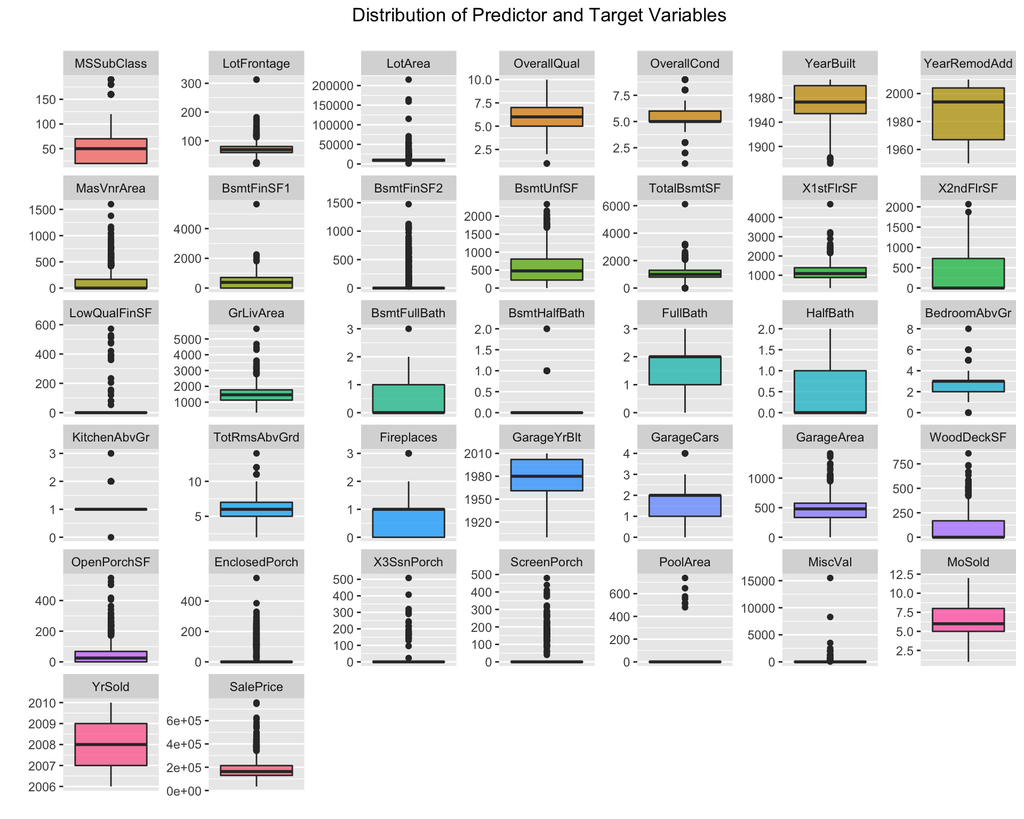

```r
ggplot(train_int_melted, aes(variable, value)) + geom_boxplot(aes(fill = variable), alpha = 0.75, show.legend = FALSE) + facet_wrap(~variable, scale="free") + scale_y_continuous('') + scale_x_discrete('', breaks = NULL) + ggtitle("Distribution of Predictor and Target Variables\n")
```

#### Provide a scatterplot of X and Y.

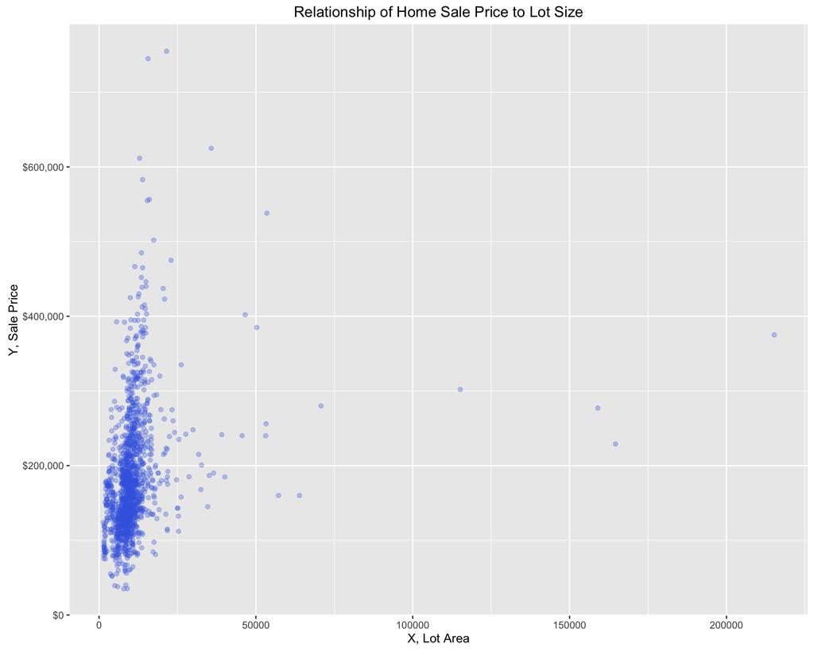

```r
ggplot(train, aes(X, Y)) + geom_point(color="royalblue", alpha=.3) + labs(list(title="Relationship of Home Sale Price to Lot Size", x = "X, Lot Area", y = "Y, Sale Price")) + scale_y_continuous(labels = scales::dollar)
```

Looking at the above scatterplot, there is a very light linear relationship between the lot size and sale price of the house. Most of the sale prices are concentrated between $100k and $300k, while the lot sizes have much less spread. The larger lot sizes do not necessarily belong to the most expensive properties, which is why we do not see a stronger correlation. In fact, there are a handful of cases where the lot size is really skewing the relationship between the variable and the sale price of the property.

#### Provide a 95% CI for the difference in the mean of the variables.

The table below shows the number of cases, mean, and standard deviation for the X and Y variables:

| VAR | n | $\bar{x}$ | $s$ |
| --- | --- | --- | --- |
| X | 1460 | 10516.83 | 9981.265 |
| Y | 1460 | 180921.2 | 79442.5 |

We can derive the point estimate (the difference in means) by subtracting the mean of Y from the mean of X.

The difference in means (point estimate) = -170404.4

To get the standard error ($SE$) of the point estimate, we take the sum of the variance divided by the sample size, and take the square root of that value:

```r
# Standard Error of Point Estimate
sqrt((var(X) / length(X)) + (var(Y) / length(Y)))
```

```
## [1] 2095.451
```

SE = 2095.451

The T-score is the point estimate divided by the standard error:

T = -170404.4 / 2095.451 = -81.321

The confidence level for the difference in means can be calculated by taking the point estimate $\pm$ the t-value associated with the degrees of freedom $\times$ the standard error. Here we will use R’s `t.test` function to calculate the 95% confidence level that the difference in means is not zero:

```r
t.test(X, Y)
```

```
##
##  Welch Two Sample t-test
##
## data:  X and Y
## t = -81.321, df = 1505.1, p-value < 2.2e-16
## alternative hypothesis: true difference in means is not equal to 0
## 95 percent confidence interval:
##  -174514.7 -166294.1
## sample estimates:
## mean of x mean of y
##  10516.83 180921.20
```

From the output, the 95% confidence interval that the true difference in means lies between -174514.7 and -166294.1. The results are negative because the mean of Y is much larger than the mean of X.

Since $\alpha$ is much smaller than 0.05, we reject the null hypothesis ($H_0$) that the difference in means is equal to zero.

#### Derive a correlation matrix for two of the quantitative variables you selected.

By combining the X (`LotArea`) and Y (`SalePrice`) variables together, a correlation matrix can be created using R’s `cor` function

```r
XY <- data.frame(X, Y)

cor_matrix <- cor(XY)
cor_matrix
```

```
##           X         Y
## X 1.0000000 0.2638434
## Y 0.2638434 1.0000000
```

The correlation matrix shows a weak positive correlation between the Lot Area and the Sale Price of the home. We might find a stronger correlation if the handful of larger lots that sold for a lesser amount were removed.

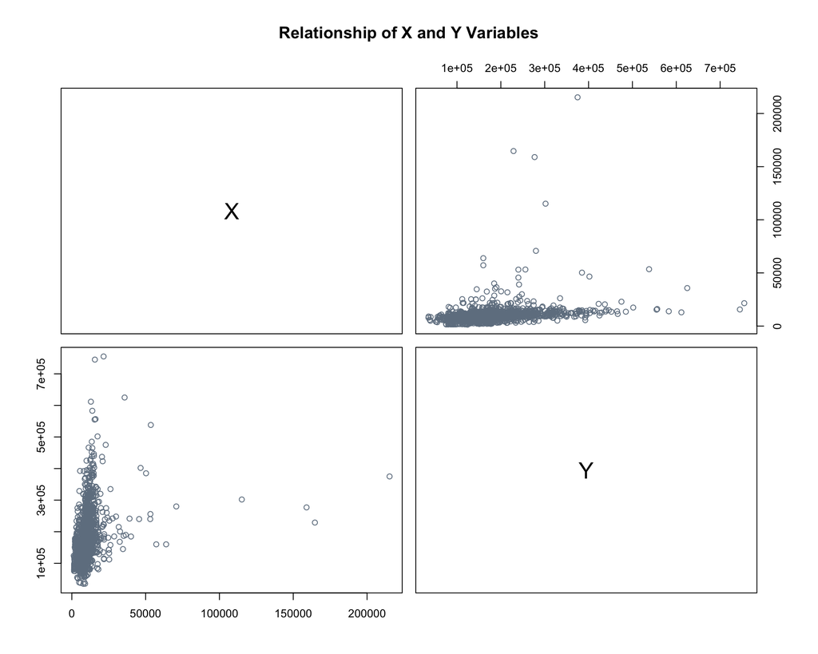

```r
# scatterplots of X-Y relationship
pairs(~X+Y, data=XY, main="Relationship of X and Y Variables", col="slategrey")
```

#### Test the hypothesis that the correlation between these variables is 0 and provide a 99% confidence interval. Discuss the meaning of your analysis.

Given a null hypothesis that there is no correlation between the X and Y variables (cor = 0), we can use Pearson’s product-moment correlation, which measures the linear dependence between variables. Using Rs `cor.test` function, we can easily calculate this correlation, and the t-test for the significance of the Pearson coefficient.

```r
cor.test(X, Y, conf.level=0.99, method="pearson")
```

```
##
##  Pearson's product-moment correlation
##
## data:  X and Y
## t = 10.445, df = 1458, p-value < 2.2e-16
## alternative hypothesis: true correlation is not equal to 0
## 99 percent confidence interval:
##  0.2000196 0.3254375
## sample estimates:
##       cor
## 0.2638434
```

The correlation coefficient is 0.2638434, which is not zero. Also, the p-value associated with the t-test is much smaller than .01. Therefore, we can reject the null hypothesis, and accept the alternative hypothesis that the correlation is not equal to zero.

The interval in which we have 99% confidence that this value lies is 0.2000196 to 0.3254375.

### Linear Algebra and Correlation.

#### Invert your correlation matrix.

**This is known as the precision matrix and contains variance inflation factors on the diagonal.**

```r
prec_matrix <- solve(cor_matrix)
prec_matrix
```

```
##            X          Y
## X  1.0748219 -0.2835846
## Y -0.2835846  1.0748219
```

This inverted correlation matrix has variance inflation factors on the diagonal, which are a function of how closely one variable is a linear function of the other variable.

#### Multiply the correlation matrix by the precision matrix, and then multiply the precision matrix by the correlation matrix.

```r
cor_matrix %*% prec_matrix
```

```
##   X Y
## X 1 0
## Y 0 1
```

```r
prec_matrix %*% cor_matrix
```

```
##   X Y
## X 1 0
## Y 0 1
```

Since the precision matrix is the inverse of the correlation matrix, multiplying the two together will result in the identity matrix, which we see in the resulting $2 \times 2$ matrix with 1s on the diagonal.

In the above process, we switched the order of multiplying the correlation and the precision matrix, both resulting in an identity matrix. This is proving that the correlation matrix is invertible, since

$A^{-1}A = I$ and $AA^{-1} = I$

#### Conduct principle components analysis (research this!) and interpret. Discuss.

When a large number of variables are present in a data set (such as the one we are currently working with), principle components analysis can help to extract important variables, or reduce dimensionality of the data. Using the real estate data, which has 1460 rows and 81 variables (columns), this would give us a 1460 x 81 matrix - that’s a lot of dimensions.

In order to perform PCA, the values of X and Y need to be adjusted so that the mean of the data is 0. This adjustment is made by subtracting the mean of each variable from the variable itself ($X - \bar{X}$).

```r
adj_X <- (X - mean(X))
adj_Y <- (Y - mean(Y))
```

The mean of each adjusted vector is just about zero. The difference is probably due to precision in the calculation:

```r
mean(adj_X)
```

```
## [1] -6.686498e-13
```

```r
mean(adj_Y)
```

```
## [1] 1.041971e-11
```

Next, the covariance matrix of the two adjusted variables is calculated. Covariance is the difference between the observed value of X and $\bar{X}$ multiplied by the difference between the observed value of Y and $\bar{Y}$. The covariance matrix is each one of these values calculated for each observation in the data, and put into a matrix in this format:

$$C^{n \times n} = (c_{i,j}, c_{i,j} = cov(Dim_{i}, Dim_{j}))$$

The covariance matrix for the X and Y variables will have the covariance between the variables themselves on the diagonal ($cov(X, X)$ and $cov(Y, Y)$), and the covariance of each variable in the other locations. Since $cov(a, b) = cov(b, a)$, we see the same value in the $2 \times 2$ matrix that is the result of these calculations:

```r
adj_XY <- data.frame(adj_X, adj_Y)

cov_adjXY <- cov(adj_XY)
cov_adjXY
```

```
##           adj_X      adj_Y
## adj_X  99625650  209211070
## adj_Y 209211070 6311111264
```

The non-diagonal values in the covariance matrix are positive, which coincides with the movement of the X and Y variables increasing together, as demonstrated previously.

Now that we have the covariance matrix, because it is a square matrix, we can calculate eigenvectors and eigenvalues of the covariance matrix.

```r
eig_cov_adjXY <- eigen(cov_adjXY)

eig_cov_adjXY$values
```

```
## [1] 6318149795   92587119
```

```r
eig_cov_adjXY$vectors
```

```
##            [,1]        [,2]
## [1,] 0.03362418 -0.99943455
## [2,] 0.99943455  0.03362418
```

The eigenvectors of the covariance matrix will give lines that fit the data in a way that a common regression line would. Below is a plot of the eigenvectors overlaid on top of the plotted adjusted data.

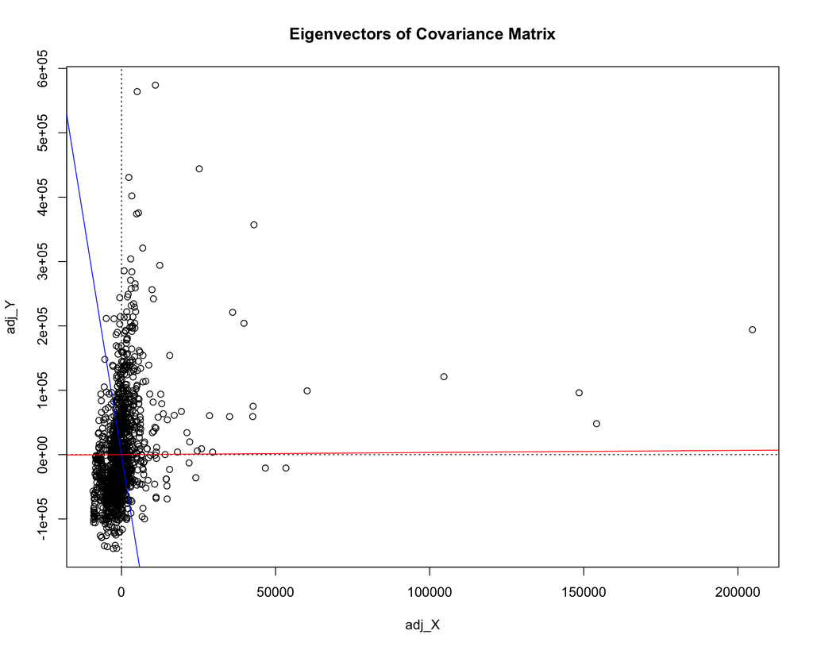

```r
plot(adj_X, adj_Y, main="Eigenvectors of Covariance Matrix"); abline(h=0, v=0, lty=3)
abline(a=0, b=(eig_cov_adjXY$vectors[1,1]/eig_cov_adjXY$vectors[2,1]), col="red")
abline(a=0, b=(eig_cov_adjXY$vectors[1,2]/eig_cov_adjXY$vectors[2,2]), col="blue")
```

The plot of eigenvectors on the plot don’t quite look orthogonal, but if we multiply the eigenvectors of the covariance matrix together, they will equal 0, meaning they are in fact, orthogonal.

```r
eig_cov_adjXY$vectors[,1] %*% eig_cov_adjXY$vectors[,2]
```

```
##      [,1]
## [1,]    0
```

The eigenvector with the higher associated eigenvalue is the first principle component of the data; this eigenvector has the most significant relationship with X and Y. In PCA, the eigenvectors are ordered by their eigenvalues, from largest to smallest.

With a larger set of variables, the principle components with smaller eigenvalues can be dropped. This will result in some loss of information, but also a dataset with reduced dimensions. Since we only have one variable and response, the first principal component explains the variability in the data. Once the principle components are decided upon, a new dataset is created using the matrix of eigenvectors transposed, multiplied by the mean-adjusted data, also transposed. What results is the data rotated so that the eigenvectors are the x and y axes.

R also has a built-in function for doing PCA, `prcomp`. This function does all of the above steps (normalizing the variables by subtracting the mean, getting the covariance matrix, then calculating the eigenvalues), and we can see the results equal the given eigenvectors calculated above:

```r
pcaXY <- prcomp(XY, center=TRUE)
pcaXY
```

```
## Standard deviations:
## [1] 79486.79  9622.22
##
## Rotation:
##           PC1         PC2
## X -0.03362418 -0.99943455
## Y -0.99943455  0.03362418
```

```r
summary(pcaXY)
```

```
## Importance of components:
##                              PC1       PC2
## Standard deviation     7.949e+04 9.622e+03
## Proportion of Variance 9.856e-01 1.444e-02
## Cumulative Proportion  9.856e-01 1.000e+00
```

### Calculus-Based Probability & Statistics.

#### For your variable that is skewed to the right, shift it so that the minimum value is above zero.

The minimum value of X (`LotArea`) is skewed to the right, but the lowest value is already above zero, as no negative lot sizes exist in the data set. In fact, none of the numerical variables have any values below 0, as indicated in the table in the descirptive statistics section.

```r
min(X)
```

```
## [1] 1300
```

#### Load the MASS package and run `fitdistr` to fit an **exponential** probability density function.

(See https://stat.ethz.ch/R-manual/R-devel/library/MASS/html/fitdistr.html).

```r
expdf <- fitdistr(X, densfun="exponential")
```

#### Find the optimal value of $\lambda$ for this distribution.

In many examples, the exponential distribution is used to explain the probability of events occurring over a period of time (time elapsed between customers, weather events, phone calls, etc.). The probability of the even occurring is proportional to the length of the interval. In other words, if an event happens six times in an hour, $\lambda = 6$, and the optimal value of $\lambda$ would be the the average wait time ($\frac{1}{\lambda}$, or 10 minutes), or the expected value.

For this distribution, a skewed variable of lot sizes in properties for sale was used. Instead of moments in time, $\lambda$ is representing the increase in size of the property’s lot area.

```r
# get value of lambda from exponential distribution
lambda <- expdf$estimate

# expected value of lambda
rate <- 1 / lambda
rate
```

```
##     rate
## 10516.83
```

#### Then, take 1000 samples from this exponential distribution using this value.

*(e.g., `rexp(1000, some_val`))*

```r
# 1000 samples from expon. dist. using lambda
expdf_samp <- rexp(1000, lambda)
```

#### Plot a histogram and compare it with a histogram of your original variable.

A histogram of the exponential fit of the original X variable (`LotArea`) is below:

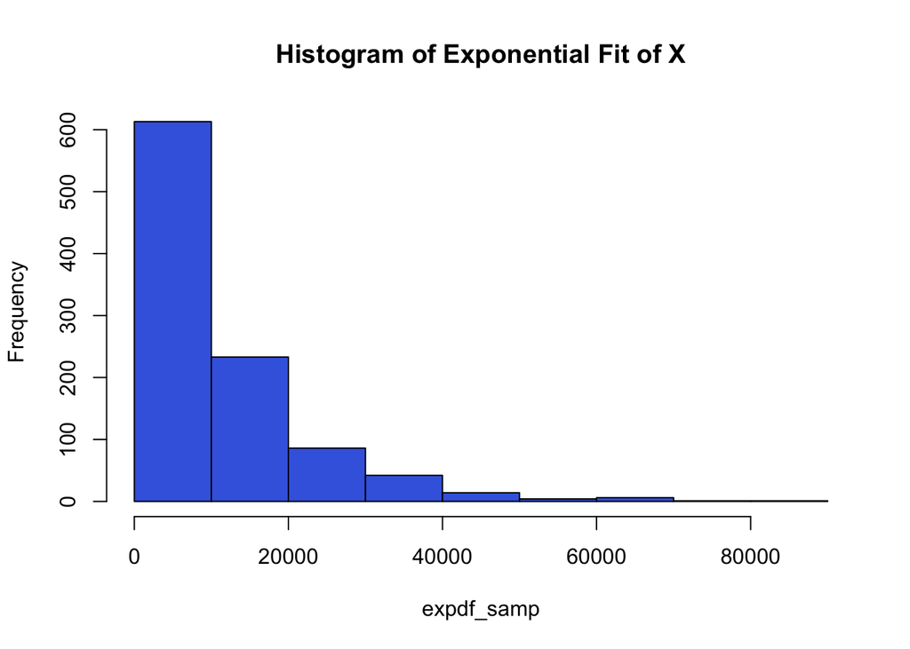

```r
hist(expdf_samp, col="royalblue", main="Histogram of Exponential Fit of X")
```

Below is a histogram of the original X variable, without the exponential fit:

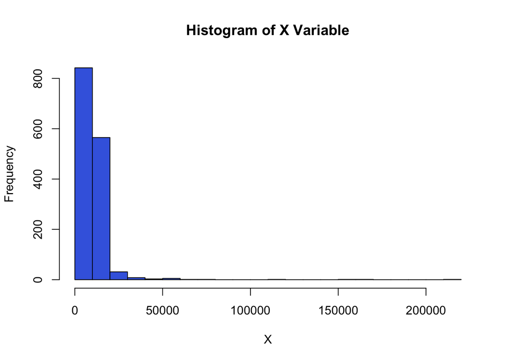

```r
hist(X, col="royalblue", main="Histogram of X Variable", breaks=20)
```

The histogram of the original X variable is right-skewed, but much more so than the exponential fit of X. Looking at summary statistics supports illustrates the difference in the spread of the data.

Summary Stats of Exponential Fit of X:

```r
summary(expdf_samp)
```

```
##     Min.  1st Qu.   Median     Mean  3rd Qu.     Max.
##     7.62  2781.00  7220.00 10710.00 14770.00 81000.00
```

Summary Stats of X:

```r
summary(X)
```

```
##    Min. 1st Qu.  Median    Mean 3rd Qu.    Max.
##    1300    7554    9478   10520   11600  215200
```